# Example 5.2 Swimming with Dolphins

Last updated Wednesday, April 09, 2025 @ 06:52 PM

## Before We Begin…

These slides are meant to accompany the text [*Introduction to Statistical Investigations, 2nd Edition*](http://www.isi-stats.com/isi/index2nd.html) — Section 5.2 Comparing Two Proportions: Simulation-Based Approach.

*This content does not replace reading the relevant textbook section.* It is for class presentation, review, and reference.

See [AsULearn](https://asulearn.appstate.edu/) for additional readings, videos, and assignments.

You can print these slides to a pdf for offline use using the print function in your browser.

## STEP 1: Ask a Research Question

[Dolphin-assisted therapy (DAT)](https://en.wikipedia.org/wiki/Swimming_with_dolphins) has been around since roughly the late 1970s. Proponents of DAT claim that interacting with dolphins can help treat a wide variety of mental and physical issues in people, but there is limited scientific evidence to back up its supposed benefits.

At least one [animal welfare organization](https://awionline.org/content/swim-attractions-dolphin-assisted-therapy) is a strong opponent, claiming that “DAT proponents foster an unproven belief that touching and being close to a dolphin has unique motivational or healthful powers, although studies show that such claims are without scientific merit.”

**Research Question:** Is swimming with dolphins therapeutic for patients suffering from clinical depression?

## STEP 2: Design a Study / Collect Data

- Researchers recruited 30 participants (ages 18–65) with a clinical diagnosis of mild to moderate depression.
- Participants discontinued antidepressants and therapy four weeks prior to and during the experiment.
- All participants went to an island off the coast of Honduras; they were randomly assigned to one of two treatment groups.
- Both groups had one hour of swimming and snorkeling each day. One group did so in the presence of bottlenose dolphins and the other group did not.
- All other conditions for the two groups (e.g., meals, lodging) were identical *except* for the presence of dolphins.
- At the end of two weeks, each subject’s level of depression was evaluated, as it had been at the beginning of the study.

## Brief Summary of Design

- **study type:** randomized experiment (*possibly single blind*)
- **experimental units:** 30 recruited subjects (ages 18–65) with a clinical diagnosis of mild to moderate depression
- **explanatory variable (treatment groups):** (1) one hour of swimming/snorkling each day *with* bottlenose dolphins, or  
  (2) one hour of swimming/snorkling each day *without* any dolphins (control group); this is a binary categorical
- **response variable:** whether or not the participants achieved substantial reduction (i.e., improvement) in their depression symptoms, coded as yes or no; this is a binary categorical
- **sample size:** \(n_{dolphin} = 15\), \(n_{control} = 15\), \(n_{total} = 30\)

## The Hypotheses: Two Expressions

**Using the association language of Chapter 4…**

- \(H_0\) : Presence of dolphins does not help (i.e., whether or not someone swims with dolphins has *no association* with their depression symptoms).
- \(H_a\) : Presence of dolphins helps (i.e., there *is an association* and swimming with dolphins will increase the probability of substantial improvement in depression symptoms).

Hypotheses expressed in this form generally would be assessed with a procedure called a \(\chi^2\) (chi-square) test, which is covered in Chapter 8 of the textbook. That test can compare two *or more* proportions — two-way tables that are larger than 2 x 2.

**Using parameters, as in Chapter 1 and Chapter 3…**

State hypotheses in words, based on the research question.

- \(H_0\) : Probability of substantial improvement after swimming with dolphins is *the same as* probability without dolphins.
- \(H_a\) : Probability of substantial improvement after swimming with dolphins is *greater than* probability without dolphins.

Now define *two* parameters in the context of the problem.

- \(\pi_\text{control}\) = probability of experiencing substantial symptom improvement after *not* swimming with dolphins
- \(\pi_\text{dolphin}\) = probability of experiencing substantial symptom improvement after swimming with dolphins

## Stating the Hypotheses With Symbols

As before, we can convert the words to symbols.

\[H_0: \pi_\text{dolphin} = \pi_\text{control}\]

\[H_a: \pi_\text{dolphin} > \pi_\text{control}\]

We are really interested in the *difference* between the groups, so the hypotheses can be expressed as a mathematical difference. Algebraically, subtract \(\pi_\text{control}\) from both sides, and we get…

\[H_0: \pi_\text{dolphin} - \pi_\text{control} = 0\]

\[H_a: \pi_\text{dolphin} - \pi_\text{control} > 0\]

The observed statistic for this test will be (\(\hat{p}_\text{dolphin} - \hat{p}_\text{control}\)).

## STEP 3: Explore the Data

Compute conditional proportions of those who demonstrated a “substantial improvement” in symptoms after two weeks, within each treatment group.

| Substantial Improvement? | Dolphin | Control | Total |
| --- | --- | --- | --- |
| Yes | 10 (66.67%) | 3 (20.00%) | 13 (43.33%) |
| No | 5 (33.33%) | 12 (80.00%) | 17 (56.67%) |
| Total | 15 (100%) | 15 (100%) | 30 (100%) |

\[\hat{p}_\text{dolphin} - \hat{p}_\text{control} = 0.6667 - 0.2000 = 0.4667\]

## Visualize With a Barplot

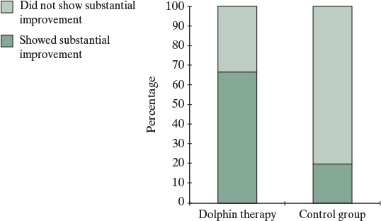

Since the groups are equal in size (\(n = 15\) each), a barplot and a mosaic plot would be essentially the same.

## STEP 4: Draw Inferences

We can use the ISI [Two-Proportion](http://www.isi-stats.com/isi2nd/ISIapplets2021.html) applet to obtain a simulated *p*-value. The two groups are shuffled together and randomly re-divided between the two treatment groups. From the regrouped data we recalculate the statistic to get a null distribution. Where would the observed difference \(0.4667\) be on this plot?

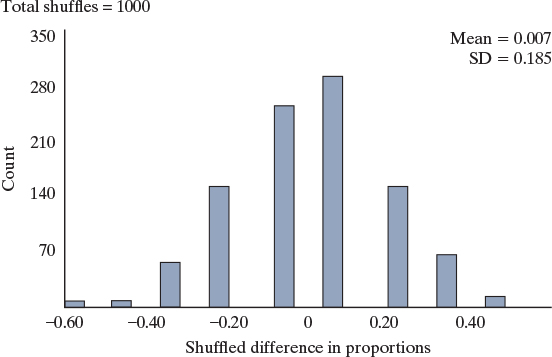

**Note:** See the last 2 slides for an example of how to use the applet.

## Assess Statistical Significance

There were 13 out of 1000 simulated differences \(\ge\) 0.4667, so the *p*-value is 0.013, which provides strong evidence against \(H_0\).

Recall our guidelines for *p*-values from Section 1.2.

| Magnitude | Guideline for Inference |
| --- | --- |
| *p*-value > 0.10 | **NOT MUCH** evidence against the null hypothesis \(H_0\) |
| 0.05 < *p*-value ≤ 0.10 | **MODERATE** evidence against the null hypothesis \(H_0\) |
| 0.01 < *p*-value ≤ 0.05 | **STRONG** evidence against the null hypothesis \(H_0\) |
| *p*-value ≤ 0.01 | **VERY STRONG** evidence against the null hypothesis \(H_0\) |

\[\text{z-score} = \frac{\text{stat} - \text{mean of null dist.}}{\text{SD of null dist.}} = \frac{0.4667 - 0}{0.185} = 2.52\]

The standardized score also yields strong evidence against \(H_0\).

Recall our guidelines for *z*-scores from Section 1.3.

| Magnitude | Strength of Evidence |
| --- | --- |
| *z* between -1.5 and +1.5 | **NOT MUCH** evidence against the null hypothesis \(H_0\) |
| *z* below -1.5 or above +1.5 | **MODERATE** evidence against the null hypothesis \(H_0\) |
| *z* below -2.0 or above +2.0 | **STRONG** evidence against the null hypothesis \(H_0\) |
| *z* below -3.0 or above +3.0 | **VERY STRONG** evidence against the null hypothesis \(H_0\) |

## Estimate Magnitude of Difference

Here we will estimate the magnitude of the difference between two parameters with a confidence interval, similar to the way we estimated one parameter. Recall what we learned in Section 3.2 about 2SD confidence intervals.

\[\text{95% CI} = \hat{p} \pm 2 \times SD(\hat{p})\]

Now our statistic is \((\hat{p}_1 - \hat{p}_2)\) rather than \(\hat{p}\), so we substitute it.

\[\text{95% CI} = (\hat{p}_1 - \hat{p}_2) \pm 2 \times SD(\hat{p}_1 - \hat{p}_2)\]

Recall: \(SD(\hat{p}_1 - \hat{p}_2)\) is a symbol for “SD of the null distribution of \((\hat{p}_1 - \hat{p}_2)\).” We get this value from our simulation.

Important: *Do not* multiply SD by \((\hat{p}_1 - \hat{p}_2)\) in the 2SD interval.

Use the difference \(\hat{p}_1 - \hat{p}_2\) = 0.4667 and simulated SD = 0.185.

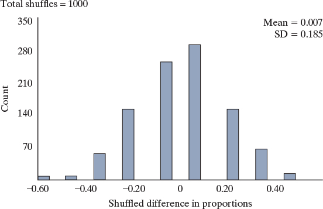

\[0.4667 \pm 2 \times 0.185 = 0.4667 \pm 0.370\]

We are 95% confident that the estimated interval (0.097, 0.837) captures the true value of \(\pi_\text{dolphin} - \pi_\text{control}\).

Notice that zero is *not* within the interval. This is consistent with rejecting \(H_0\). Zero is not a plausible value for the difference.

## STEP 5: Formulate Conclusions

Recall — In Section 4.2 we learned about how random selection and random assignment influence conclusions about cause and effect and generalization for a given study.

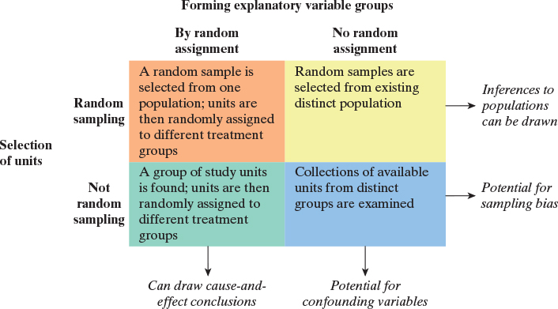

## Discussion of Findings

This study was a randomized experiment and the data provided strong evidence against the null hypothesis, so we can conclude that swimming with dolphins *caused* a significant improvement in depression symptoms aong participants.

The magnitude of the difference in the probability that a patient will show significant improvement is between 9.7% and 83.7%. *To get a narrower interval, we would need more data.*

We can also compute the relative risk, which is \(\frac{0.6667}{0.2000} = 3.33\).

Participants in the dolphin therapy treatment group were 3.33 times as likely to improve compared to the control subjects.

However, participants were *not* randomly selected, so we would be limited in our ability to generalize these results.

## Two-Proportion Applet: Data and Plots

Enter the two-way table in the applet and choose Use Table to use the data in the analysis. Notice *Observed Diff in proportions*.

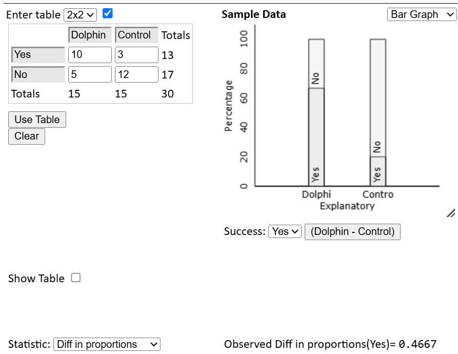

## Two-Proportion Applet: Significance

Choose at least 1000 shuffles (repetitions of the simulation), and enter the observed difference in the Count Samples box. Make sure the sign matches alternative hypothesis.

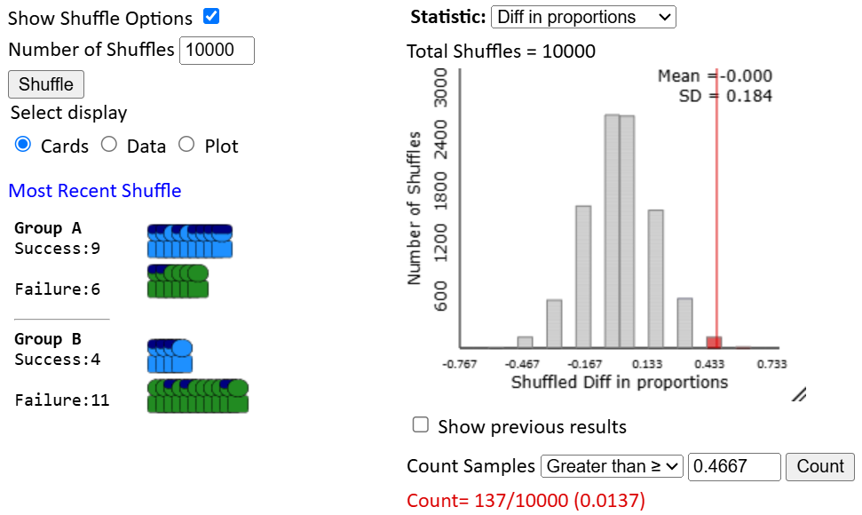

The *p*-value is \(0.0137\), very similar to the earlier \(0.013\) *p*-value.